# Welcome to Data Science Computing!

Lecture 01: Introduction

Danilo Freire

danilo.freire@emory.edu

Department of Data and Decision Sciences  
Emory University

# Welcome to DATASCI 350: Data Science Computing! 🎉

## Lecture overview

### Today’s agenda

- Introduction
- Motivation
- Class logistics
- Computer setup

## Course materials

### Important links

Course website: https://danilofreire.github.io/datasci350

Course repository: https://github.com/danilofreire/datasci350

The syllabus, the schedule and all the lecture slides are available [on our website](https://danilofreire.github.io/datasci350)

The assignments, project guidelines and study guides are available [on our GitHub repository](https://github.com/danilofreire/datasci350)

We will use Canvas for course administration, including submitting assignments, accessing grades, and receiving announcements

Please take some time to get to know all three platforms, and reach out if you have any questions 😉

**Note**

Please remember to check the course repository regularly for updates and announcements!

# Nice to meet you! 😊

## Instructor

### A bit about me

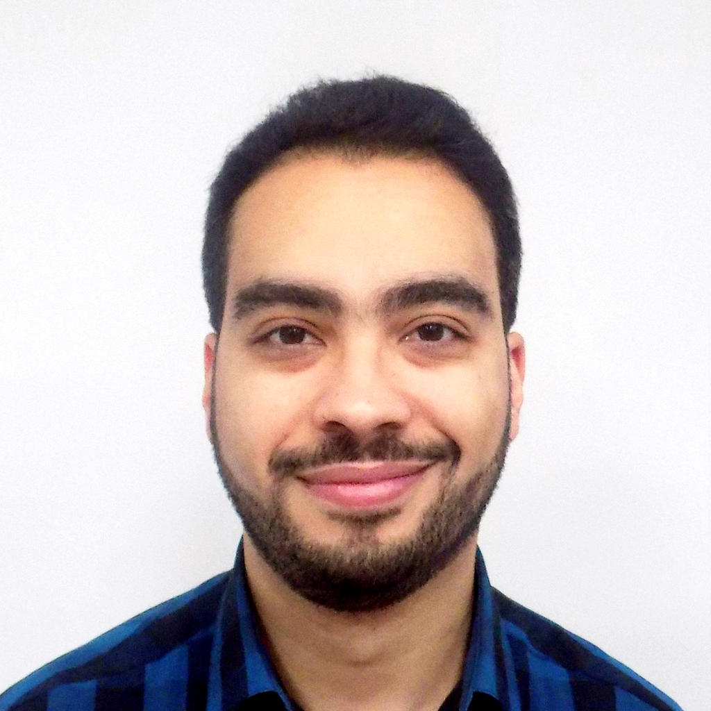

danilo.freire@emory.edu

https://danilofreire.github.io/

https://github.com/danilofreire/

Visiting Assistant Professor in the [Department of Data and Decision Sciences](https://quantitative.emory.edu)

MA from the Graduate Institute Geneva, PhD from King’s College London, Postdoc at Brown University, Senior Lecturer at the University of Lincoln, UK

Research interests: computational social science, experimental methods, policy evaluation, political violence, organised crime

## What about you? (time permitting!)

Now it’s your turn! 😉

Please introduce yourself! 👋

Tell us your name, your major, one thing you really like, and something we don’t know about your city or country! 🌍

## My teaching philosophy

- I love teaching and aim to make learning fun
- Classes where students participate are the best!
- Hands-on activities help you learn better
- I am always available to help and answer questions. And I mean it
- Your feedback helps me improve my teaching. Please let me know what is working and what is not

## Teaching assistants

- The teaching assistants for this course will be announced soon
- They will be available to help you with assignments, quizzes, and any questions you may have about the course material
- We are all here to help you! So feel free to ask questions during class, office hours, or via email 😃

## Office hours

### What for and what not for

- What office hours are meant for:
  - Applying tools in practice
  - Discussion of issues related to the assignments
  - Boosting your knowledge of data science
- What these sessions are not meant for:
  - Solving the assignments for you
  - Taking care of developing your coding skills

## Class etiquette

- Coding can be tough and push you out of your comfort zone. If the course pace is too fast, let me know. I expect your commitment, but I do not want anyone to fail
- You are all keen on data science, but your backgrounds vary. That is great! Some sessions might be more engaging than others. If you are bored, help others or explore new data science areas
- Always be respectful to each other
- Ask questions whenever you need to!

[figure not shown]

# Motivation: What is data science? 👨🏻‍💻👩🏼‍💻

## An old classic

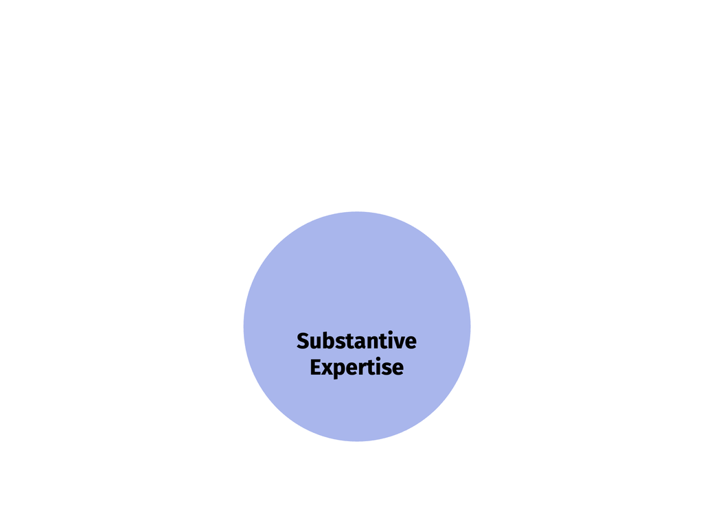

## An old classic

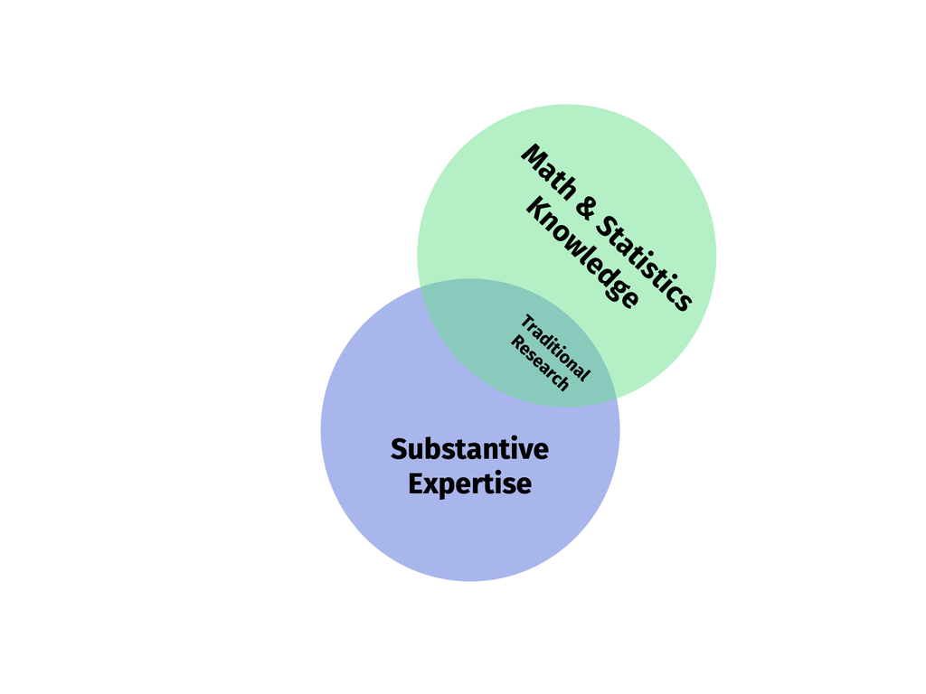

## An old classic

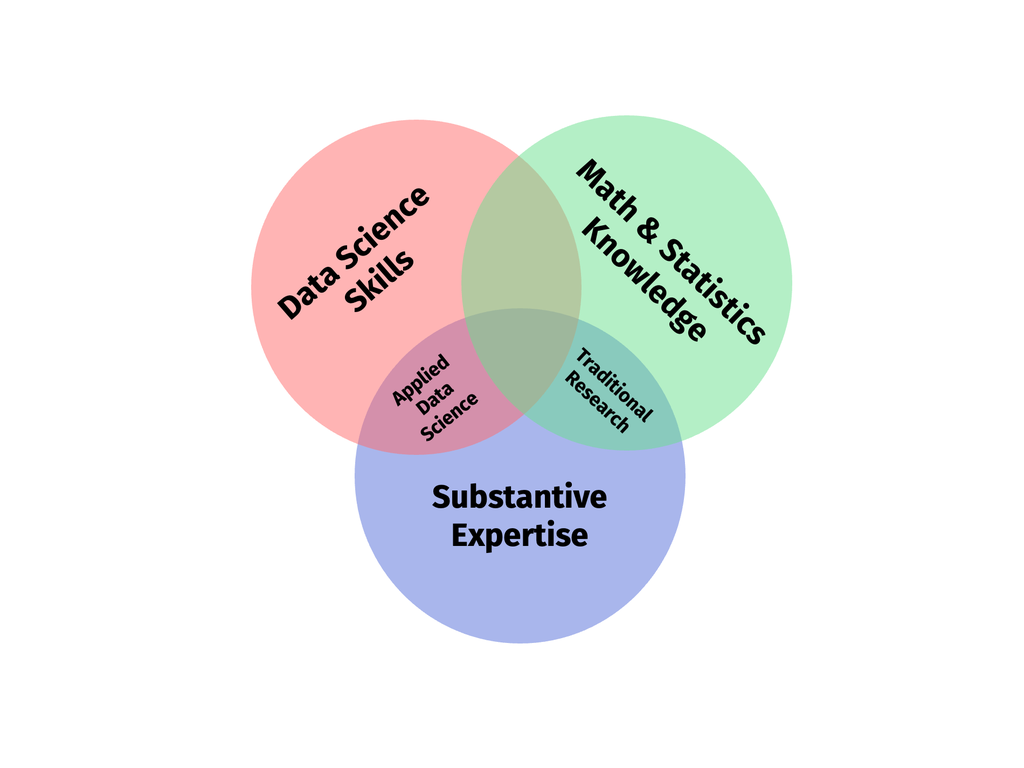

## An old classic

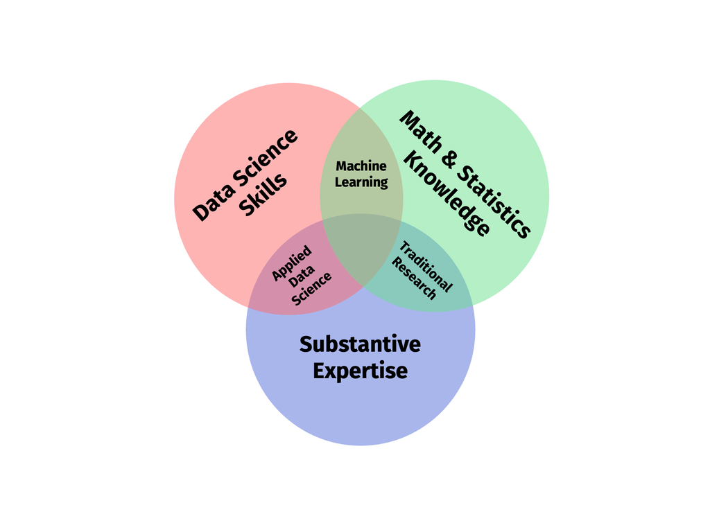

## An old classic

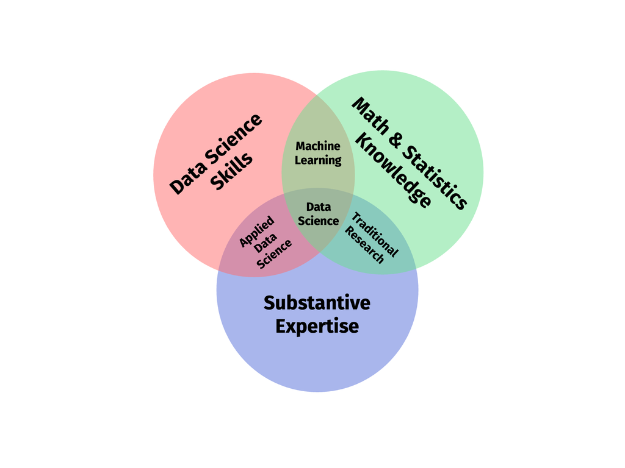

## Our focus!

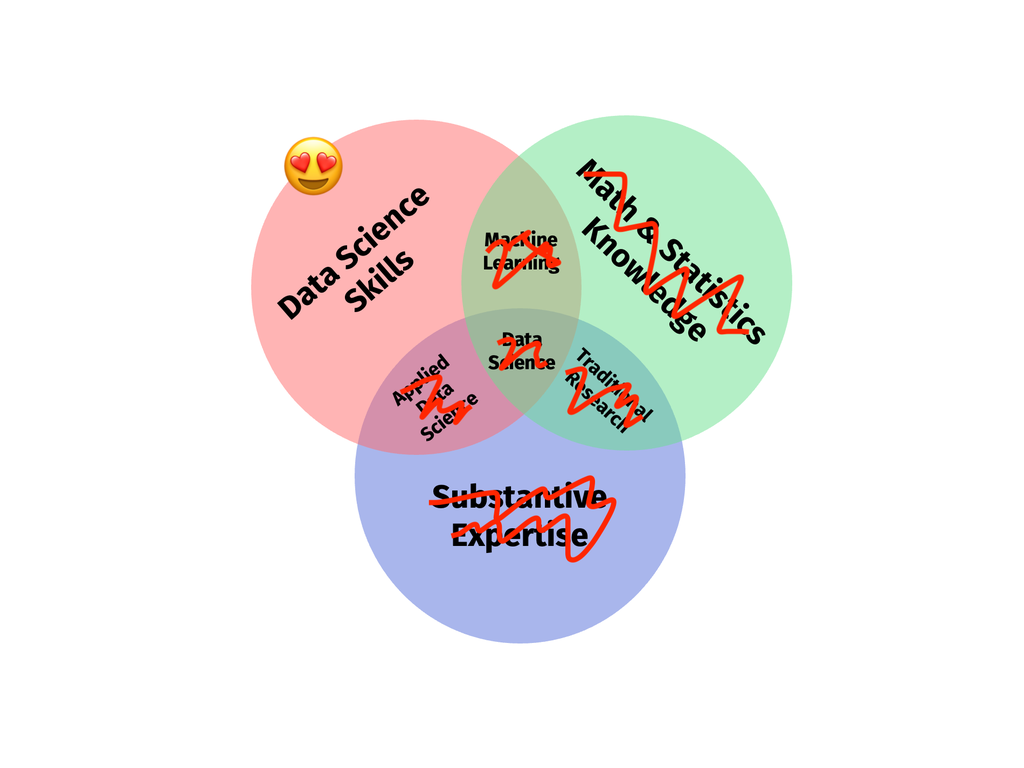

## Rise of the digital information age

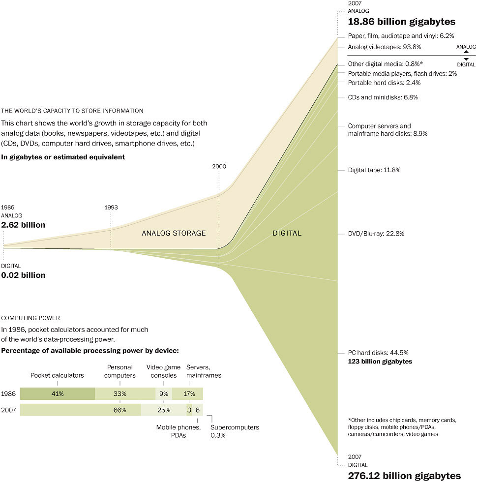

## Social media data

[figure not shown]

## New data formats

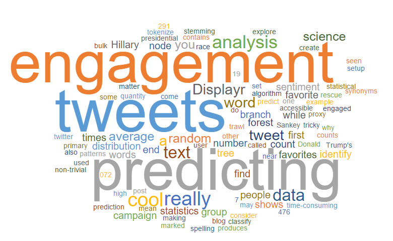

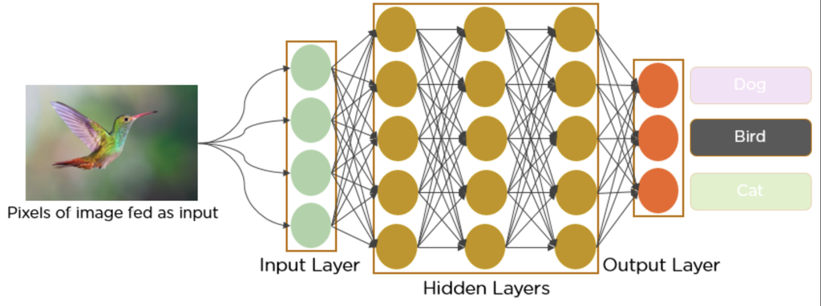

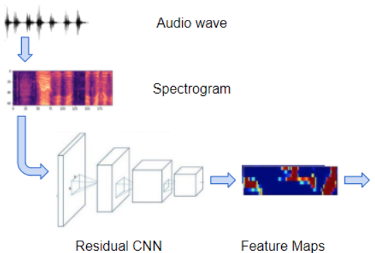

## Survey data

[figure not shown]

## Cheap computing power

[figure not shown]

# And what can we do with all these data? 🤔

## Scraping the web for social research

[figure not shown]

## Tackling social problems

[figure not shown]

## Reducing hate speech

[figure not shown]

## Monitoring the effects of climate change on health

[figure not shown]

## Calling bullsh*t when you see it

Learn not to be fooled by

- big data
- garbage data
- garbage models
- weird samples
- claims of generality
- implausibly large effect sizes
- overfitted models

And much more…

[figure not shown]

## And much more…

- Abundance of data available for research and for governments to make better decisions
  - Opportunities for novel research questions
  - New methods to answer longstanding research questions
- New technologies also have social implications and can raise important policy issues
  - Ethical concerns
  - Use of technology by malicious actors
  - Government use of technology to censor or monitor citizens

# Course overview and logistics 📖 📚 💻

## Course objectives

- Use the command line interface to manage files and directories
- Work with version control systems to track changes in code and collaborate with others
- Create reproducible reports and presentations
- Run and call language models from your own code
- Collect data from web APIs and process it at scale
- Run your own server in the cloud and package your work with containers

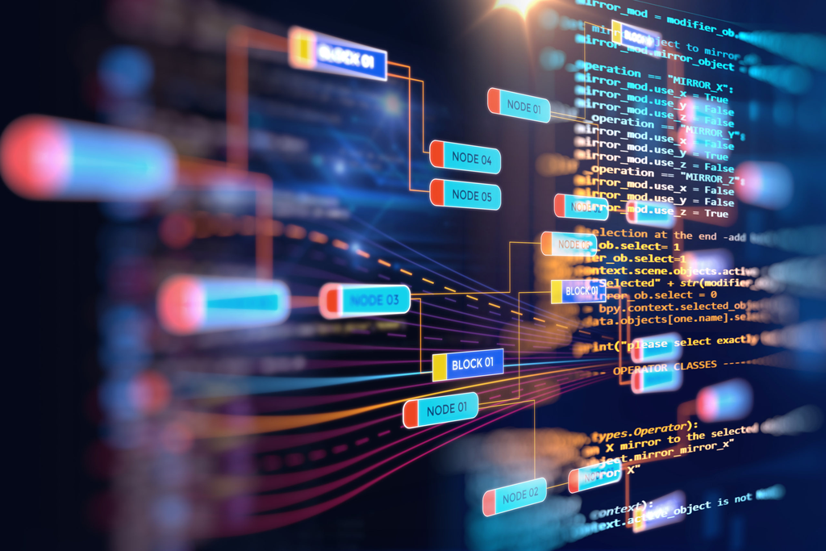

## Key focus areas

- This course centres around three key areas of the modern data science workflow: reliability, reproducibility, and robustness
- Reliability:
  - Ensures consistency in results across multiple runs
  - Minimises errors in data processing and analysis
  - Supports accurate interpretation of findings
- Reproducibility:
  - Allows others to verify and build upon your work
  - Enhances the credibility of research outcomes
  - Facilitates long-term preservation of scientific knowledge
- Robustness:
  - Enables analyses to handle unexpected data variations
  - Improves the stability of results under different conditions
  - Supports the scalability of methods to larger datasets

## Key tools

- [Command-line interfaces](https://en.wikipedia.org/wiki/Command-line_interface) and bash shell for precise control

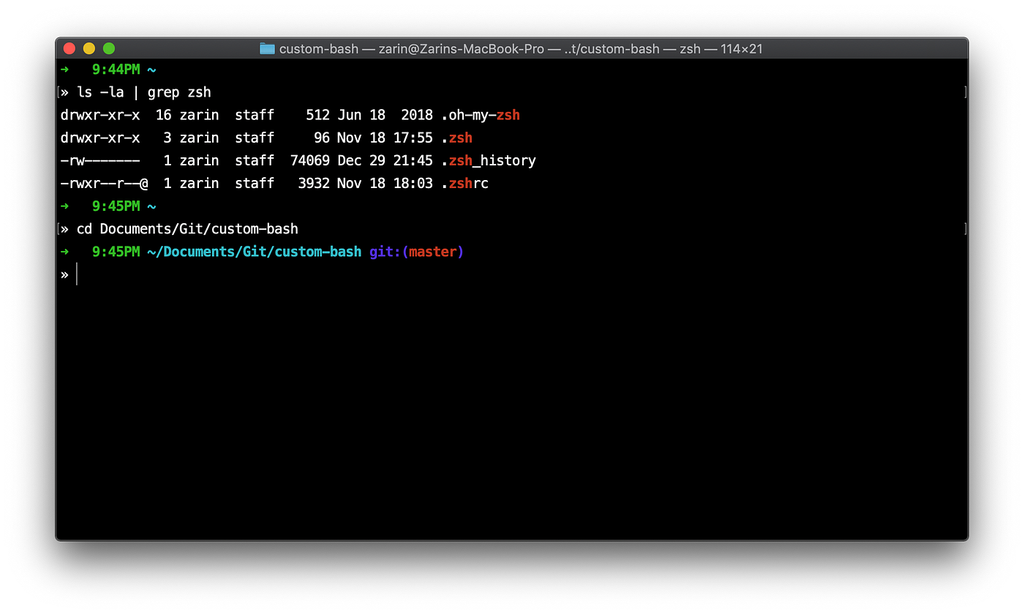

[figure not shown]

## Key tools

- [Git](https://git-scm.com/) and [GitHub](https://github.com) for version control and collaboration

[figure not shown]

[figure not shown]

## Key tools

- [Ollama](https://ollama.com/) to run language models on your own laptop, and [OpenRouter](https://openrouter.ai/) to call hosted ones from Python

[figure not shown]

[figure not shown]

## Key tools

- [Quarto](https://quarto.org/) and [Jupyter Notebooks](https://jupyter.org/) for interactive computing

[figure not shown]

## Key tools

- [requests](https://requests.readthedocs.io/) for collecting data from web APIs

[figure not shown]